# EDA: Human Activity Recognition - Weight Lifting

```r
# Code imports
library(dplyr)
```

# Introduction

This EDA was done as a way to help me in the project of the course [Pratical Machine Learning](https://www.coursera.org/learn/practical-machine-learning/home/welcome).

The final report, that should be gradded, can be viewed be at https://anbarbosabr.github.io/PraticalMachineLearning/

# Objectives

The goal of the project is, as stated on the Coursera’s Project Instructions, to identify how a weight lifting exercise was done using accelerometers data.

Looking at the webside of the source of the data, [Groupware@LES website](http://groupware.les.inf.puc-rio.br/har#weight_lifting_exercises), I could identify that the exercise that is being executed is the *Unilateral Dumbbell Biceps Curl*.

Also, the classes are:

- Class A: exactly according to the specification.
- Class B: throwing the elbows to the front.
- Class C: lifting the dumbbell only halfway.
- Class D: lowering the dumbbell only halfway.
- Class E: throwing the hips to the front.

If you do not know what kind of exercise it is, neither did I, so a quickly google helped me:

[video not shown]

It´s important to note that, in this project, the provided test dataset has only 20 rows.

PS: It came to my mind that, since the test data has only 20 observations, I am not supposed to consider this data as a time series.

# The Data EDA

For the EDA, I will use only the training data provided by John Hopkins.

```r
training_data = readr::read_csv(
                        here::here("data/pml-training.csv"),
                        col_types = readr::cols(
                          .default = readr::col_double(),
                          user_name = readr::col_character(),
                          classe = readr::col_factor(),
                          raw_timestamp_part_1 = readr::col_integer(),
                          raw_timestamp_part_2 = readr::col_integer(),
                          cvtd_timestamp = readr::col_datetime(format = "%d/%m/%Y %H:%M"),
                          new_window = readr::col_character()))
```

It contains 19622 rows and 160. There is a lot of data. Let´s see how the data looks like:

```r
dplyr::glimpse(training_data)
```

```
## Rows: 19,622
## Columns: 160
## $ X1                       <dbl> 1, 2, 3, 4, 5, 6, 7, 8, 9, 10, 11, 12, 13,...
## $ user_name                <chr> "carlitos", "carlitos", "carlitos", "carli...
## $ raw_timestamp_part_1     <int> 1323084231, 1323084231, 1323084231, 132308...
## $ raw_timestamp_part_2     <int> 788290, 808298, 820366, 120339, 196328, 30...
## $ cvtd_timestamp           <dttm> 2011-12-05 11:23:00, 2011-12-05 11:23:00,...
## $ new_window               <chr> "no", "no", "no", "no", "no", "no", "no", ...
## $ num_window               <dbl> 11, 11, 11, 12, 12, 12, 12, 12, 12, 12, 12...
## $ roll_belt                <dbl> 1.41, 1.41, 1.42, 1.48, 1.48, 1.45, 1.42, ...
## $ pitch_belt               <dbl> 8.07, 8.07, 8.07, 8.05, 8.07, 8.06, 8.09, ...
## $ yaw_belt                 <dbl> -94.4, -94.4, -94.4, -94.4, -94.4, -94.4, ...
## $ total_accel_belt         <dbl> 3, 3, 3, 3, 3, 3, 3, 3, 3, 3, 3, 3, 3, 3, ...
## $ kurtosis_roll_belt       <dbl> NA, NA, NA, NA, NA, NA, NA, NA, NA, NA, NA...
## $ kurtosis_picth_belt      <dbl> NA, NA, NA, NA, NA, NA, NA, NA, NA, NA, NA...
```

[output cut: 147 more lines]

Also, let´s see if there was any problem with the end of the file:

```r
knitr::kable(tail(training_data))
```

| X1 | user_name | raw_timestamp_part_1 | raw_timestamp_part_2 | cvtd_timestamp | new_window | num_window | roll_belt | pitch_belt | yaw_belt | total_accel_belt | kurtosis_roll_belt | kurtosis_picth_belt | kurtosis_yaw_belt | skewness_roll_belt | skewness_roll_belt.1 | skewness_yaw_belt | max_roll_belt | max_picth_belt | max_yaw_belt | min_roll_belt | min_pitch_belt | min_yaw_belt | amplitude_roll_belt | amplitude_pitch_belt | amplitude_yaw_belt | var_total_accel_belt | avg_roll_belt | stddev_roll_belt | var_roll_belt | … |
| --- | --- | --- | --- | --- | --- | --- | --- | --- | --- | --- | --- | --- | --- | --- | --- | --- | --- | --- | --- | --- | --- | --- | --- | --- | --- | --- | --- | --- | --- | --- |
| 19617 | adelmo | 1322832937 | 588324 | 2011-12-02 13:35:00 | no | 864 | 148 | -34.7 | 129 | 21 | NA | NA | NA | NA | NA | NA | NA | NA | NA | NA | NA | NA | NA | NA | NA | NA | NA | NA | NA | … |
| 19618 | adelmo | 1322832937 | 588376 | 2011-12-02 13:35:00 | no | 864 | 147 | -34.8 | 129 | 21 | NA | NA | NA | NA | NA | NA | NA | NA | NA | NA | NA | NA | NA | NA | NA | NA | NA | NA | NA | … |
| 19619 | adelmo | 1322832937 | 596287 | 2011-12-02 13:35:00 | no | 864 | 145 | -35.3 | 130 | 19 | NA | NA | NA | NA | NA | NA | NA | NA | NA | NA | NA | NA | NA | NA | NA | NA | NA | NA | NA | … |
| 19620 | adelmo | 1322832937 | 636283 | 2011-12-02 13:35:00 | no | 864 | 145 | -35.5 | 130 | 19 | NA | NA | NA | NA | NA | NA | NA | NA | NA | NA | NA | NA | NA | NA | NA | NA | NA | NA | NA | … |
| 19621 | adelmo | 1322832937 | 964299 | 2011-12-02 13:35:00 | no | 864 | 143 | -35.9 | 131 | 18 | NA | NA | NA | NA | NA | NA | NA | NA | NA | NA | NA | NA | NA | NA | NA | NA | NA | NA | NA | … |
| 19622 | adelmo | 1322832937 | 972293 | 2011-12-02 13:35:00 | yes | 864 | 143 | -36.0 | 132 | 18 | -1.175902 | -1.063259 | NA | 0.19686 | -0.572396 | NA | 132 | 25 | -1.2 | 123 | 18 | -1.2 | 9 | 7 | 0 | 5.6268 | 151.1481 | 4.7532 | 22.5926 | … |

This quick view already showed me that:

1. I can discart the X1 variable, which is an row id
2. Most of the variables are numeric
3. There is some rule for the naming of the sensors variables, that I need to understand better.
4. There are tree timestamp variables.
5. There are a lot of missing values on some of the variables, mainly on those that seems to be aggregated values (avg, var, stddev, amplitude…).
6. There are two window variables, I may use then instead of creating my own windows. Probably the aggregated values are calculated by using these windows.

## Variables

```r
# The "profile" variables
profile_variables = names(training_data)[c(1:7, 160)]
profile_variables
```

```
## [1] "X1"                   "user_name"            "raw_timestamp_part_1"
## [4] "raw_timestamp_part_2" "cvtd_timestamp"       "new_window"
## [7] "num_window"           "classe"
```

As already said: - *X1*: is just an ID, so it´s not important. - *user_name*: may be important to capture the differences between the subjects and try to remove some of the noise, but will not help us to make new predictions. - *raw_timestamp_part_1, raw_timestamp_part_2, cvtd_timestamp*: timestamp variables - *classe*: The class variable, from A to E.

```r
# Counting distinct values for those variables
sapply(training_data[profile_variables], function(x) length(unique(x)))
```

```
##                   X1            user_name raw_timestamp_part_1
##                19622                    6                  837
## raw_timestamp_part_2       cvtd_timestamp           new_window
##                16783                   20                    2
##           num_window               classe
##                  858                    5
```

We can confirm that X1 is an ID, it has one unique value for each row in the data. We have all 6 subjects. new window is a boolean(yes/no) We have 858 windows of time, approximately one for each 22.9 rows.

### Sensors

Since there are 152 sensor related variables, it will help to understand them.

Here is the list of all variables:

```r
sensors_variables = names(training_data)[-c(1:7, 160)]
sensors_variables
```

```
##   [1] "roll_belt"                "pitch_belt"
##   [3] "yaw_belt"                 "total_accel_belt"
##   [5] "kurtosis_roll_belt"       "kurtosis_picth_belt"
##   [7] "kurtosis_yaw_belt"        "skewness_roll_belt"
##   [9] "skewness_roll_belt.1"     "skewness_yaw_belt"
##  [11] "max_roll_belt"            "max_picth_belt"
##  [13] "max_yaw_belt"             "min_roll_belt"
##  [15] "min_pitch_belt"           "min_yaw_belt"
##  [17] "amplitude_roll_belt"      "amplitude_pitch_belt"
##  [19] "amplitude_yaw_belt"       "var_total_accel_belt"
##  [21] "avg_roll_belt"            "stddev_roll_belt"
##  [23] "var_roll_belt"            "avg_pitch_belt"
##  [25] "stddev_pitch_belt"        "var_pitch_belt"
##  [27] "avg_yaw_belt"             "stddev_yaw_belt"
##  [29] "var_yaw_belt"             "gyros_belt_x"
```

[output cut: 61 more lines]

It seems that the sensors are divided in:

- belt
- arm
- forearm
- dumbbel

And there are aggregations

- kurtosis: for roll, pitch, yaw
- skewness: for roll, pitch(except for belt), yaw. Note that there is a skewness_roll_belt.1 column, and there is NOT a skewness_pitch_belt. This seems like a case of mislabeled column, and the skewness_roll_belt.1 should be skewness_pitch_belt, but I wont make any assumptions unless I can confirm it. (I can confront with original dataset, if this variable seems useful.)
- max: for roll, pitch, yaw
- min: for roll, pitch, yaw
- amplitude: for roll, pitch, yaw
- var: for roll, pitch, yaw, total_accel
- avg: for roll, pitch, yaw
- std: for roll, pitch, yaw

```r
sensors_variables[grep("belt", sensors_variables)]
```

```
##  [1] "roll_belt"            "pitch_belt"           "yaw_belt"
##  [4] "total_accel_belt"     "kurtosis_roll_belt"   "kurtosis_picth_belt"
##  [7] "kurtosis_yaw_belt"    "skewness_roll_belt"   "skewness_roll_belt.1"
## [10] "skewness_yaw_belt"    "max_roll_belt"        "max_picth_belt"
## [13] "max_yaw_belt"         "min_roll_belt"        "min_pitch_belt"
## [16] "min_yaw_belt"         "amplitude_roll_belt"  "amplitude_pitch_belt"
## [19] "amplitude_yaw_belt"   "var_total_accel_belt" "avg_roll_belt"
## [22] "stddev_roll_belt"     "var_roll_belt"        "avg_pitch_belt"
## [25] "stddev_pitch_belt"    "var_pitch_belt"       "avg_yaw_belt"
## [28] "stddev_yaw_belt"      "var_yaw_belt"         "gyros_belt_x"
## [31] "gyros_belt_y"         "gyros_belt_z"         "accel_belt_x"
## [34] "accel_belt_y"         "accel_belt_z"         "magnet_belt_x"
## [37] "magnet_belt_y"        "magnet_belt_z"
```

```r
# By sensor type
belt_variables = sensors_variables[grep("belt", sensors_variables)]
arm_variables = sensors_variables[grep("_arm", sensors_variables, perl = TRUE)]
forearm_variables = sensors_variables[grep("forearm", sensors_variables)]
dumbbell_variables = sensors_variables[grep("dumbbell", sensors_variables)]

data.frame(sort(belt_variables), sort(arm_variables), sort(forearm_variables), sort(dumbbell_variables))
```

| sort.belt_variables. | sort.arm_variables. | sort.forearm_variables. | sort.dumbbell_variables. |
| --- | --- | --- | --- |
| accel_belt_x | accel_arm_x | accel_forearm_x | accel_dumbbell_x |
| accel_belt_y | accel_arm_y | accel_forearm_y | accel_dumbbell_y |
| accel_belt_z | accel_arm_z | accel_forearm_z | accel_dumbbell_z |
| amplitude_pitch_belt | amplitude_pitch_arm | amplitude_pitch_forearm | amplitude_pitch_dumbbell |
| amplitude_roll_belt | amplitude_roll_arm | amplitude_roll_forearm | amplitude_roll_dumbbell |
| amplitude_yaw_belt | amplitude_yaw_arm | amplitude_yaw_forearm | amplitude_yaw_dumbbell |
| avg_pitch_belt | avg_pitch_arm | avg_pitch_forearm | avg_pitch_dumbbell |
| avg_roll_belt | avg_roll_arm | avg_roll_forearm | avg_roll_dumbbell |
| avg_yaw_belt | avg_yaw_arm | avg_yaw_forearm | avg_yaw_dumbbell |
| gyros_belt_x | gyros_arm_x | gyros_forearm_x | gyros_dumbbell_x |

[output cut: 28 more lines]

```r
# By Measure Type, note that some variables has pitch mispelled as picth.
roll_variables = sensors_variables[grep("roll", sensors_variables)]
pitch_variables = sensors_variables[grep("pitch|picth", sensors_variables)]
yaw_variables = sensors_variables[grep("yaw", sensors_variables)]

c(length(roll_variables), length(pitch_variables), length(yaw_variables))
```

```
## [1] 37 35 36
```

The number of roll variables, pitch variables and yaw variables reinforces the hipotesis that one “pitch” variable was mislabeled as a “roll” variable.

```r
# By Measure Type
accel_variables = sensors_variables[grep("accel", sensors_variables)]
gyros_variables = sensors_variables[grep("gyros", sensors_variables)]
magnet_variables = sensors_variables[grep("magnet", sensors_variables)]

cbind(sort(accel_variables), c(sort(gyros_variables), rep(NA, 8)), c(sort(magnet_variables), rep(NA, 8)))
```

```
##       [,1]                   [,2]               [,3]
##  [1,] "accel_arm_x"          "gyros_arm_x"      "magnet_arm_x"
##  [2,] "accel_arm_y"          "gyros_arm_y"      "magnet_arm_y"
##  [3,] "accel_arm_z"          "gyros_arm_z"      "magnet_arm_z"
##  [4,] "accel_belt_x"         "gyros_belt_x"     "magnet_belt_x"
##  [5,] "accel_belt_y"         "gyros_belt_y"     "magnet_belt_y"
##  [6,] "accel_belt_z"         "gyros_belt_z"     "magnet_belt_z"
##  [7,] "accel_dumbbell_x"     "gyros_dumbbell_x" "magnet_dumbbell_x"
##  [8,] "accel_dumbbell_y"     "gyros_dumbbell_y" "magnet_dumbbell_y"
##  [9,] "accel_dumbbell_z"     "gyros_dumbbell_z" "magnet_dumbbell_z"
## [10,] "accel_forearm_x"      "gyros_forearm_x"  "magnet_forearm_x"
## [11,] "accel_forearm_y"      "gyros_forearm_y"  "magnet_forearm_y"
## [12,] "accel_forearm_z"      "gyros_forearm_z"  "magnet_forearm_z"
## [13,] "total_accel_arm"      NA                 NA
## [14,] "total_accel_belt"     NA                 NA
## [15,] "total_accel_dumbbell" NA                 NA
## [16,] "total_accel_forearm"  NA                 NA
## [17,] "var_accel_arm"        NA                 NA
## [18,] "var_accel_dumbbell"   NA                 NA
## [19,] "var_accel_forearm"    NA                 NA
## [20,] "var_total_accel_belt" NA                 NA
```

```r
# sum(c(length(accel_variables), length(gyros_variables), length(magnet_variables)))
```

We have accel in the x, y and z coordinates, and also a total_accel. The total accel is the magnitude of the acceleration vector: $\sqrt{x^2+y^2+z^2}$. Note that we also have the var of the accelerations.

```r
# By Aggregation
kurtosis_variables = sensors_variables[grep("kurtosis", sensors_variables)]
skewness_variables = sensors_variables[grep("skewness", sensors_variables)]
max_variables = sensors_variables[grep("max", sensors_variables)]
min_variables = sensors_variables[grep("min", sensors_variables)]
amplitude_variables = sensors_variables[grep("amplitude", sensors_variables)]
var_variables = sensors_variables[grep("var", sensors_variables)]
avg_variables = sensors_variables[grep("avg", sensors_variables)]
std_variables = sensors_variables[grep("std", sensors_variables)]

aggregated_variables = c(kurtosis_variables, skewness_variables, max_variables, min_variables, amplitude_variables, var_variables, avg_variables, std_variables)

c(length(kurtosis_variables), length(skewness_variables), length(max_variables), length(min_variables), length(amplitude_variables), length(var_variables), length(avg_variables), length(std_variables))
```

```
## [1] 12 12 12 12 12 16 12 12
```

As expected, the only kind of aggregation that has more variables than the others is the variance.

#### Timestamps

[output not shown]

```r
timestamp_variables = profile_variables[grep("timestamp", profile_variables)]
summary(training_data[timestamp_variables])
```

```
##  raw_timestamp_part_1 raw_timestamp_part_2 cvtd_timestamp
##  Min.   :1.322e+09    Min.   :   294       Min.   :2011-11-28 14:13:00
##  1st Qu.:1.323e+09    1st Qu.:252912       1st Qu.:2011-11-30 17:11:00
##  Median :1.323e+09    Median :496380       Median :2011-12-02 13:35:00
##  Mean   :1.323e+09    Mean   :500656       Mean   :2011-12-02 11:58:10
##  3rd Qu.:1.323e+09    3rd Qu.:751891       3rd Qu.:2011-12-05 11:24:00
##  Max.   :1.323e+09    Max.   :998801       Max.   :2011-12-05 14:24:00
```

```r
part1.timestamp <- training_data$raw_timestamp_part_1
part1.datetime <- lubridate::as_datetime(part1.timestamp)
head(data.frame(training_data$cvtd_timestamp, part1.datetime))
```

|  | training_data.cvtd_timestamp | part1.datetime |
| --- | --- | --- |
| 1 | 2011-12-05 11:23:00 | 2011-12-05 11:23:51 |
| 2 | 2011-12-05 11:23:00 | 2011-12-05 11:23:51 |
| 3 | 2011-12-05 11:23:00 | 2011-12-05 11:23:51 |
| 4 | 2011-12-05 11:23:00 | 2011-12-05 11:23:52 |
| 5 | 2011-12-05 11:23:00 | 2011-12-05 11:23:52 |
| 6 | 2011-12-05 11:23:00 | 2011-12-05 11:23:52 |

#### Windows

Let´s see how many rows we have per window of time:

```r
rows_per_window = training_data %>% group_by(num_window) %>% summarise(contagem = n())
```

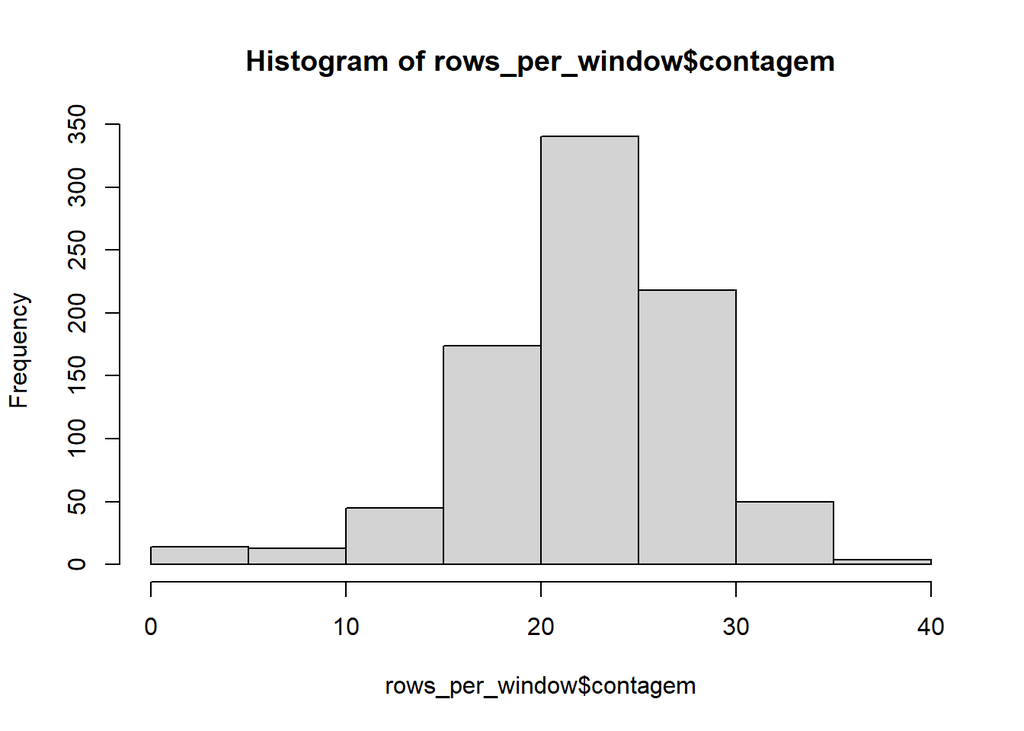

```r
hist(rows_per_window$contagem)
```

## Pre-Selected Variables

```r
all_variables <- names(training_data)

id_variables <- c("X1", "user_name") # Username wont help creating a model that generalizes well.

time_variables <- c("raw_timestamp_part_1", "raw_timestamp_part_2", "cvtd_timestamp", "new_window", "num_window")

aggregation_preffix <-  "kurtosis|skewness|max|min|amplitude|var|avg|std"
aggregation_variables <- grep(aggregation_preffix, all_variables)
aggregation_variables <- all_variables[aggregation_variables]

to_remove_variables <- c(id_variables, time_variables, aggregation_variables)
keep_variables <- setdiff(all_variables, to_remove_variables)

training_data <- training_data[keep_variables]
```

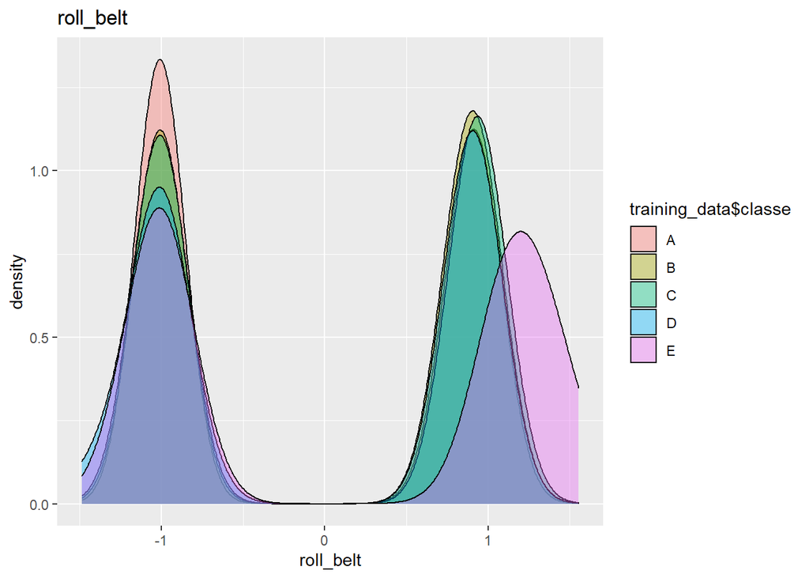

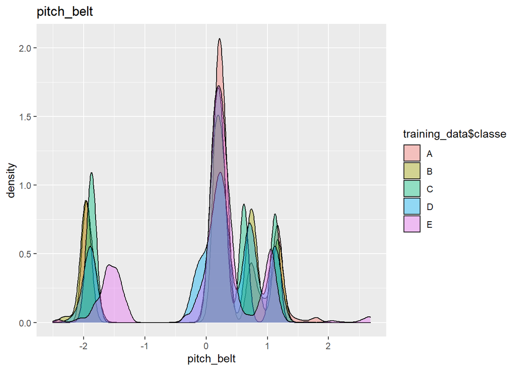

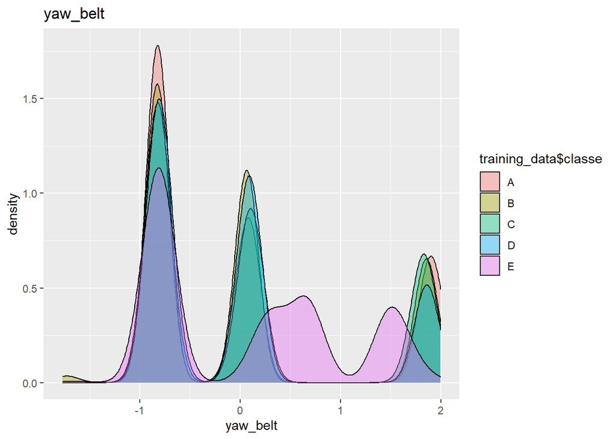

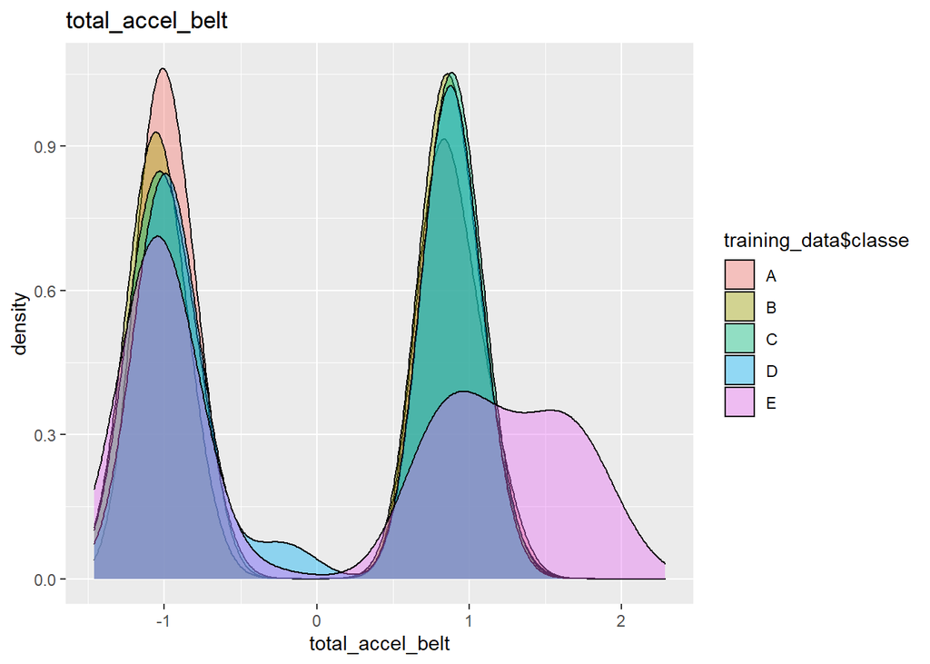

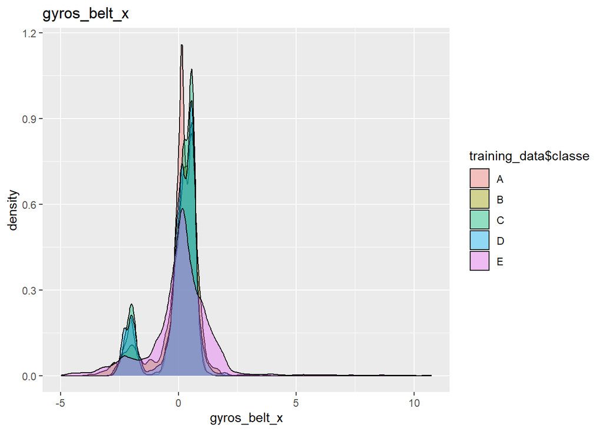

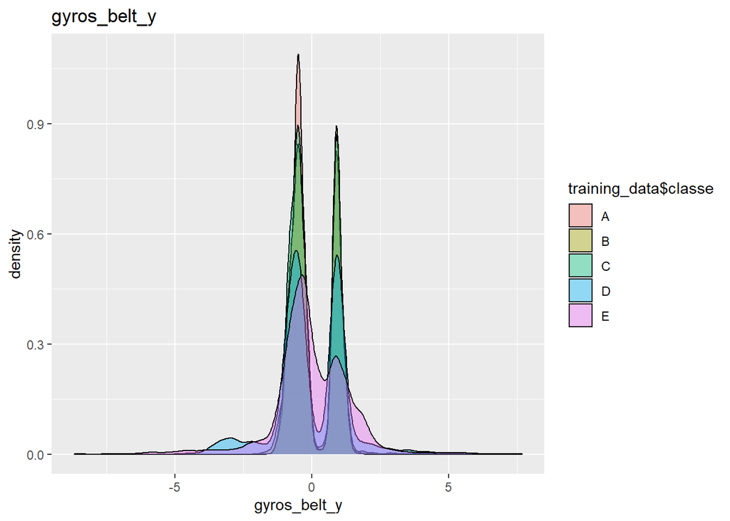

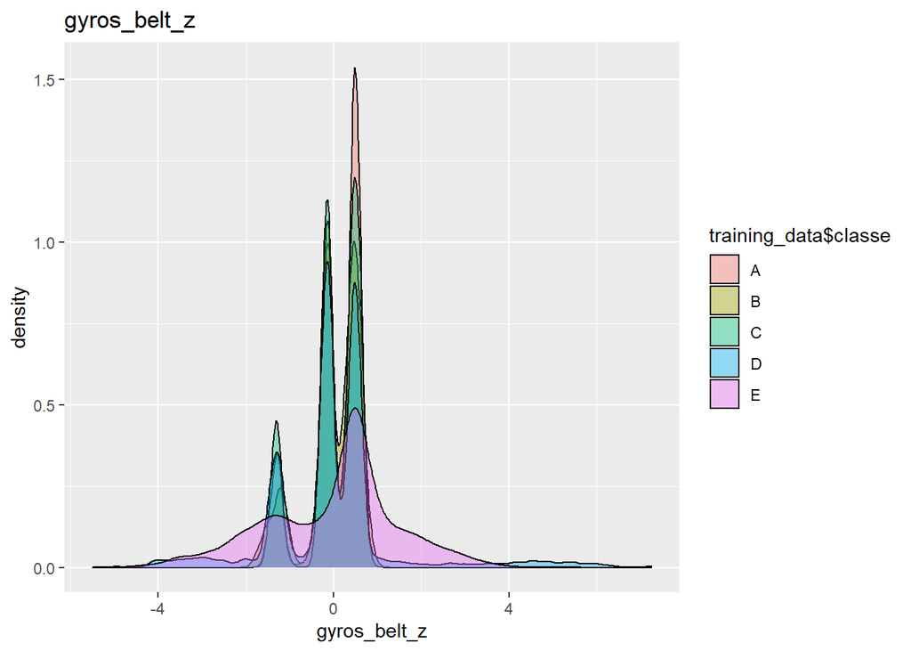

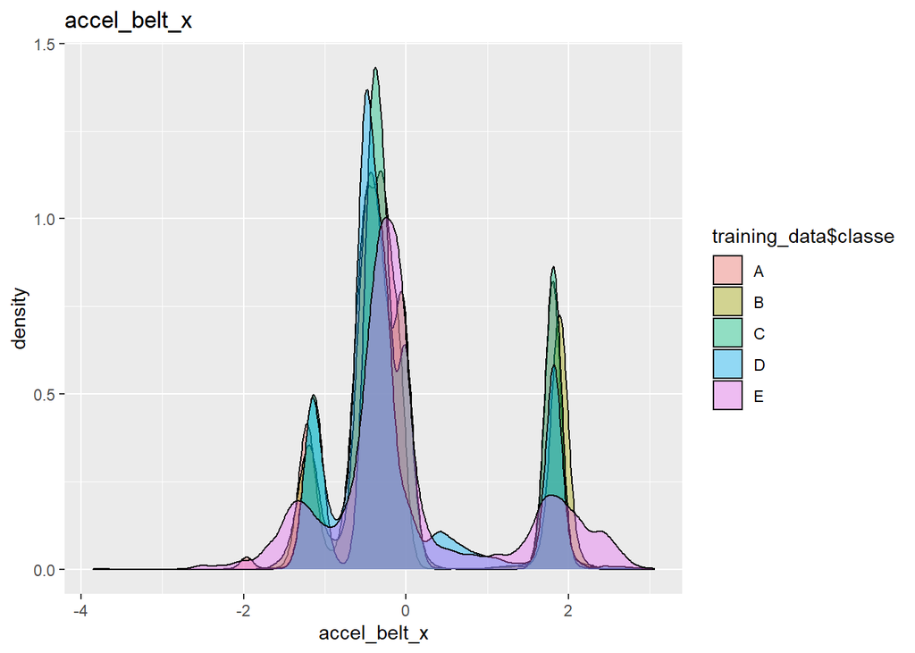

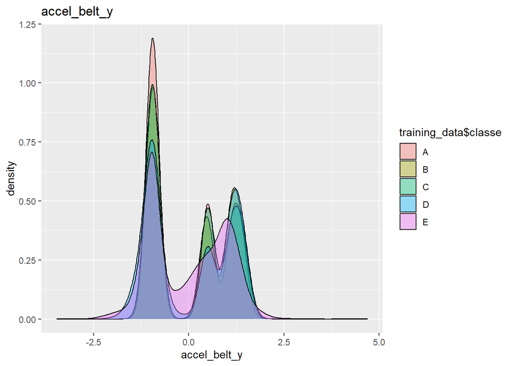

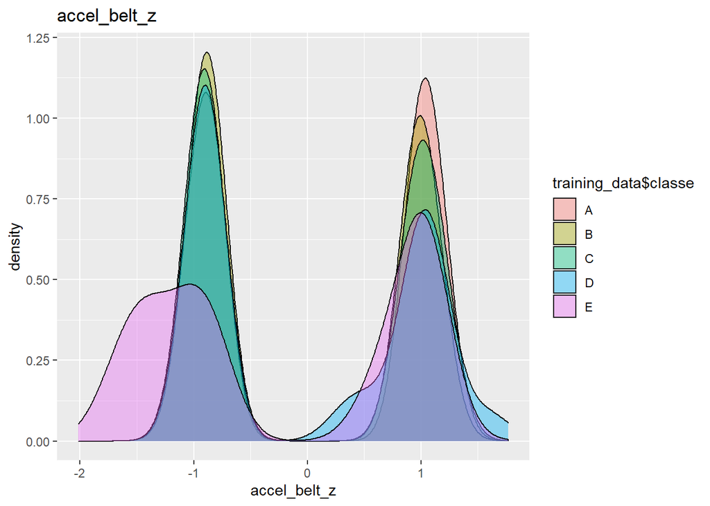

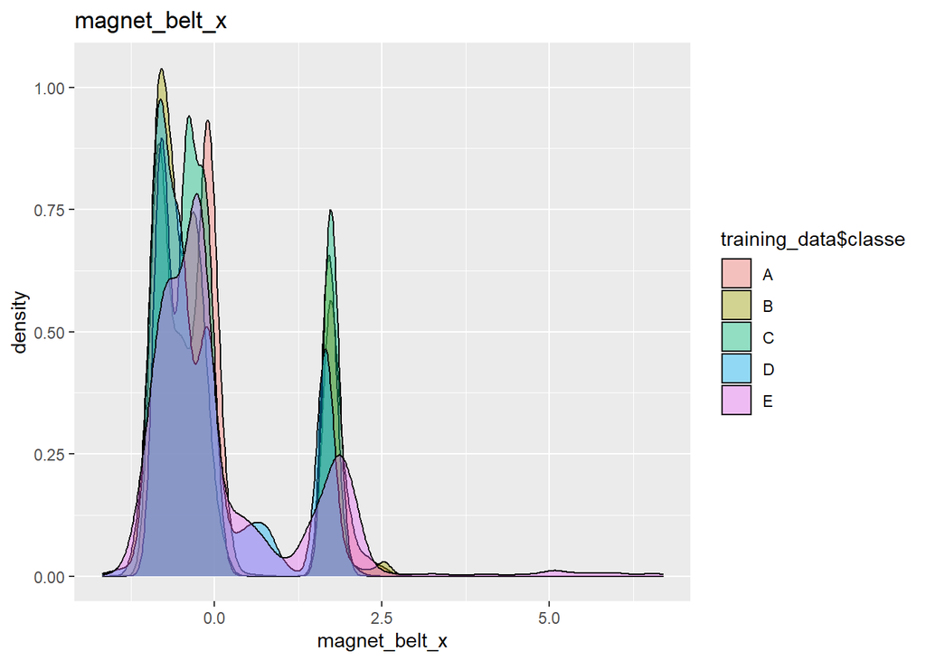

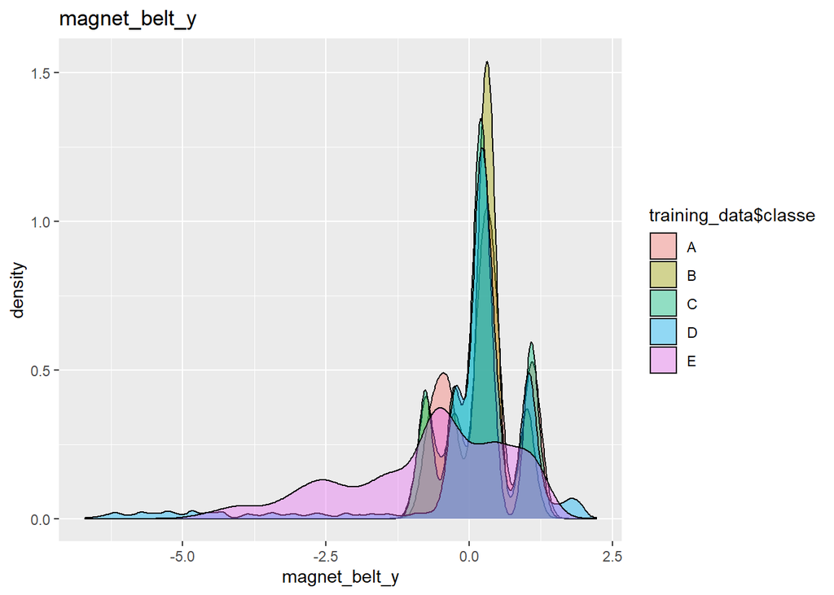

[40 more figures not shown]

```r
# Centering and scaling before ploting:
class_column_index = 53
x_data = training_data[-class_column_index]
prepro = caret::preProcess(x_data, c("center","scale"))
scaled_data <- predict(prepro, x_data)

# GGally::ggpairs(scaled_data, ggplot2::aes(color = training_data$classe), alpha = 0.4)
for (variable in names(scaled_data)){
  p = ggplot2::ggplot(scaled_data, ggplot2::aes_string(x=variable))
  p = p + ggplot2::geom_density(ggplot2::aes(fill=training_data$classe), alpha = 0.4)
  p = p + ggplot2::ggtitle(variable)
  print(p)
}
```

### Missings

There are any missings, besides the aggregated variables:

```r
sapply(training_data, function(x) {sum(is.na(x))})
```

```
##            roll_belt           pitch_belt             yaw_belt
##                    0                    0                    0
##     total_accel_belt         gyros_belt_x         gyros_belt_y
##                    0                    0                    0
##         gyros_belt_z         accel_belt_x         accel_belt_y
##                    0                    0                    0
##         accel_belt_z        magnet_belt_x        magnet_belt_y
##                    0                    0                    0
##        magnet_belt_z             roll_arm            pitch_arm
##                    0                    0                    0
##              yaw_arm      total_accel_arm          gyros_arm_x
##                    0                    0                    0
##          gyros_arm_y          gyros_arm_z          accel_arm_x
##                    0                    0                    0
##          accel_arm_y          accel_arm_z         magnet_arm_x
##                    0                    0                    0
##         magnet_arm_y         magnet_arm_z        roll_dumbbell
##                    0                    0                    0
##       pitch_dumbbell         yaw_dumbbell total_accel_dumbbell
##                    0                    0                    0
##     gyros_dumbbell_x     gyros_dumbbell_y     gyros_dumbbell_z
##                    0                    0                    0
##     accel_dumbbell_x     accel_dumbbell_y     accel_dumbbell_z
##                    0                    0                    0
##    magnet_dumbbell_x    magnet_dumbbell_y    magnet_dumbbell_z
##                    0                    0                    0
##         roll_forearm        pitch_forearm          yaw_forearm
##                    0                    0                    0
##  total_accel_forearm      gyros_forearm_x      gyros_forearm_y
##                    0                    0                    0
##      gyros_forearm_z      accel_forearm_x      accel_forearm_y
##                    0                    0                    0
##      accel_forearm_z     magnet_forearm_x     magnet_forearm_y
##                    0                    0                    0
##     magnet_forearm_z               classe
##                    0                    0
```